# Optimization with Genetic Algorithm

Arga Adyatama

12/23/2019

# 1 Introduction

## 1.1 About

Optimization is important in many fields, including in data science. In manufacturing, where every decision is critical to the process and the profit of organization, optimization is often employed, from the number of each products produced, how the unit is scheduled for production, get the best or optimal process parameter, and also the routing determination such as the traveling salesman problem. In data science, we are familiar with model tuning, where we tune our model in order to improve the model performance. Optimization algorithm can help us to get a better model performance. Genetic Algorithm (GA) is one of the widely used optimization algorithm.

This article is an attempt to explain the mechanism behind one of the most effective algorithm for optimization problems: Genetic Algorithm (GA). There are many algorithm specifically created for optimization, such as the Particle Swarm Optimization (PSO), Simulated Annealing (SA), and Tabu Search. However, in many areas, GA can achieve the objective better than said methods. There are various derivative and variation of GA implementation, with perhaps the most famous one is the implementation of GA in multiobjective optimization problem, where we want to optimize two objective simultaneously, called Multi Objective Evolutionary Algorithm (MOEA). We will see how a general GA works and where it can be applied, either on business problems and on the data science field.

## 1.2 Objectives

Learning Objective:

- Learn the importance of optimization in business
- Learn about cost function/objective function and decision variables
- Learn the relationship between machine learning and optimization
- Learn the principle and concepts of Genetic Algorithm
- Learn the implementation of GA in business case and data science field

## 1.3 Library and Setup

To use GA, you can install `GA` package using the `install.packages()` function.

The following is the packages that will be used throughout the articles.

```r
library(tidyverse)
library(GA)
library(ranger)
library(tidymodels)
library(caret)
library(tictoc)
```

# 2 Optimization Problem

## 2.1 Why Optimization is Important

Say, we have 2 line of product, with product A has profit of USD 50 while product B has profit of USD 30. We want to maximize our profit, but we have limited resources. We only have 80 hours of work for a week, with product A take about 10 hours in making while product B is 4 hours in making. Both product shares the same materials and we have only 100 meters of fabric with each product A requires 2 meters of fabric while product B requires 4 meters of fabric. How do we decide what is the best number of product A and B to be produced? Such is the optimization problem (in these case, optimize the profit).

What if we decide to randomly select the quantities of each products to be produced. We may don’t have enough time to finish it. We may don’t have enough materials, or the opposite could happen: we may have spare materials.

Another case, say we want to deliver our product the some warehouses. How do we decide which warehouse should we visit first or how do we decide what route should we take in order to minimize the delivery time?

Optimization are important especially if we have limited resources. More importanly, optimization concern with profit and loss: choosing the wrong delivery route will result in late delivery, which may incur penalty cost or damaging our products along the way. That’s why optimization is really important for business.

## 2.2 Objective Function and Decision Variables

Every optimization problem always has 2 elements: objective function and decision variables. Objective function mean how do we formulate our goals, like how do we measure profit in order to maximize it, or how do we measure delivery time in order to minimize it. Inside the objective function there exist decision variables, what should be our decision that can result in maximal profit? We want to maximize our goals by choosing the right decision variables. In the previous example, the goal to maximize profit belong to the objective function, while the number of product A and product B to be produced belong to the decision variables.

Some objective may have a constraint, like the number of workhours a week is only 80 hours or the number of materials available is only 100 meters. The constraint is important, since any solution that doesn’t meet the constraint is an infeasible solution.

## 2.3 Machine Learning and Optimization

Machine learning and optimization cannot be separated, they are related to each other, although the goal is different. Machine learning is concerned with prediction or classification based on several predictors, while optimization is concerned with finding the best objective value based on the choice of decision variables. However, the mechanism behind most of machine learning models are optimization. For example, the gradient descent method of Neural Network training model is an optimization method, one which goal is to find the lowest point and converge. Another example is the linear regression fitting, which minimize the sum of squared error (thus, the name Least Square method).

Machine learning can be improved by tuning the hyper-parameter with optimization, while at the same time optimization method also can be improved with machine learning models. For example, we can significantly reduce the MSE of Standard and Weighted K-NN Regression model by employing Genetic Algorithm[^1]. With multi-objective optimization, we can acquire an ensemble model that has balanced trade-off between runtime and model performance[^2].

# 3 Genetic Algorithm: Concepts

## 3.1 Overview

Let’s first read this beautiful paragraph from *The Blind Watchmaker* by Richard Dawkins

> “All appearances to the contrary, the only watchmaker in nature is the blind forces of physics, albeit deployed in very special way. A true watchmaker has foresight: he designs his cogs springs, and plans their interconnections, with a future purpose in his mind’s eye. Natural selection, the blind, unconscious, automatic process which Darwin discovered, and which we now know is the explanation for the existence and apparently purposeful form of all life, has no purpose in mind. It has no mind and no mind’s eye. It does not plan for the future. It has no vision, no foresight, no sight at all. If it can be said to play the role of watchmaker in nature, it is the blind watchmaker.”

Evolution by natural selection is first proposed by Charles Darwin through his book *On the Origin of Species by Means of Natural Selection, or the Preservation of Favoured Races in the Struggle for Life*. Despite the bold statement by Dawkins that natural selection has no purpose, the mechanism can be adapted to solve optimization problem. If in real biological world, natural selection work unpurposely by selecting the fittest individual that can survive and reproduce, thus spreading it’s genes, the optimal or best solution in optimization problem can be acquired by selecting those with the **fittest** value, namely the value of objective function(s). This perhaps is the main difference between the actual natural selection and the one adopted for Genetic Algorithm.

> “Genetic algorithms (GAs) are stochastic search algorithms inspired by the basic principles of biological evolution and natural selection. GAs simulate the evolution of living organisms, where the fittest individuals dominate over the weaker ones, by mimicking the biological mechanisms of evolution, such as selection, crossover and mutation.”

Genetic Algorithm is an optimization algorithm that use the concept of evolution by natural selection. Evolution by natural selection, as proposed by Darwin, is the mechanism on how many varieties of living things are adapting to their environment to survive, through 2 main principles: natural selection and random mutation. The genetic algorithm (GA) borrowed the concept and use it to gain optimal solutions by selecting the best or the fittest solution alongside the rare and random occurence of mutation.

Suppose we have a non-convex function. If we use a derivative-based method such as gradient descend, it would potentially fall into local optima at $x_1$. Genetic Algorithm can overcome the local optima, thus it can provide better solution. Combined with machine learning such as neural network, GA can create an arfiticial intelligence system that can play game, like [Flappy Bird](https://www.youtube.com/watch?v=aeWmdojEJf0)

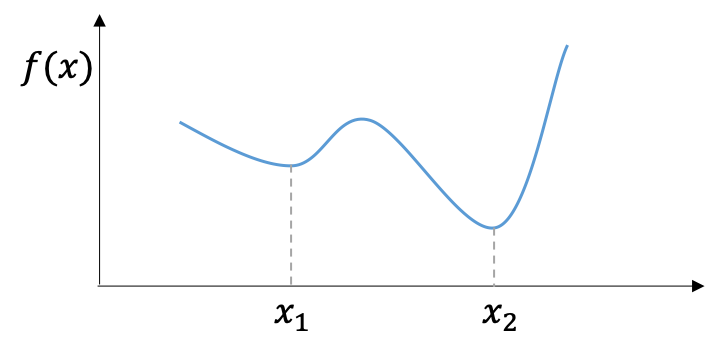

The general flow of the algorithm is shown below:

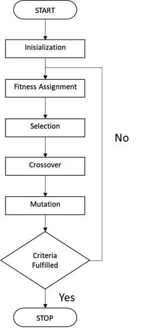

1. There will be a population of randomly selected chromosomes or solutions.
2. The fitness values or the objective function values from each solutions are calculated.
3. From the population, two of the solutions will be chosen as **parent solutions**, either by tournament selection or any other selection methods.
4. The chosen solutions will be crossed to create new solutions, called **child solutions**.
5. The child solutions may change due to the random mutations (that has really low probability to happen).
6. In the end of the iteration, new population will be chosen from the **parent solutions** or the initial population and the **child solutions** based on the fitness values.
7. As long as the stopping criterion is not fulfilled, usually in term of number of iterations, the algorithm will continue to iterate.
8. Best or optimal solutions are those with the optimal fitness value.

There are several advantages of Genetic Algorithm:

- Genetic Algorithm can escape local optima
- Can handle complex problem with many decision variables and big solution space
- It considers many points in the searching space simultaneously, not a single point, to deal with large parameter spaces.
- Can be parallelized since GA consists of multiple chromosomes/solutions
- Support multi-objective optimization

## 3.2 Elements

There exist 3 main elements of GA: Population, Chromosomes, and Genes.

Population is a group of individuals or solutions, mainly called chromosomes. A chromosomes consists of a sequence of genes, with each or multiple genes (depend on the encoding) represent a single decision variables that will be fitted on the objective functions.

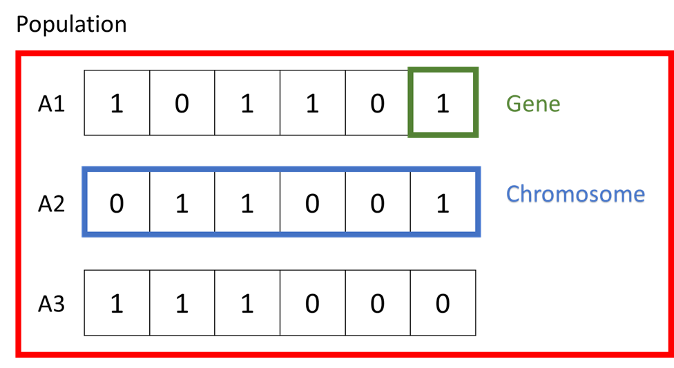

A gene can be represented or encoded in various ways, including:

- Binary Encoding

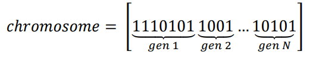

Binary encoding mean that our genes are encoded into binary number, this is the earliest and the most common form of GA encoding.

- Real-Valued Encoding

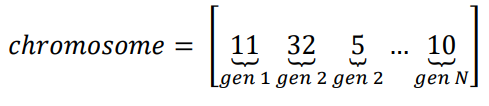

Real-valued encoding mean that our genes are encoded in a floating point or decimal number. Real-valued encoding can be used to optimize a process parameter, since it consists of floating point number and are not suited for integer-based optimization.

- Permutation Encoding

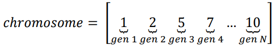

Permutation encoding mean that our genes are encoded into a sequence of number, each number is uniquely assigned to a gene so no 2 genes that will have the same number or value. This encoding is often used in a scheduling or routing problem, where each permutation represent one location or unique points.

## 3.3 Selection

Parents selections are done in order to select two solutions that will be used for crossover to create new solutions called **child solutions**. There are several methods to choose parents:

- Roulette Wheel Selection

Parents will be selected randomly based on the fitness value. Higher fitness value mean higher chance to be chosen.

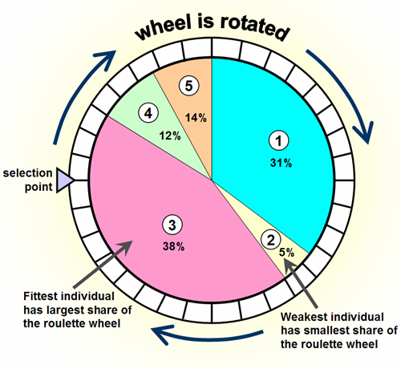

- Linear Ranking Selection

Individuals are assigned subjective fitness based on the rank within the population. The individuals in the population are sorted from best to worst based on their fitness values. Each individual in the population is assigned a numerical rank based on fitness, and selection is based on this ranking rather than differences in fitness.

- Tournament Selection

Tournament selection is done by selecting a set of chromosomes from population and make certain selection criterion. Tournament selection is effective for GAs with that has big population because there is no need to sort the individuals inside the population.

## 3.4 Crossover and Mutation

### 3.4.1 Crossover

Crossover is the process of mating between the two selected individuals, the process represents how genes are transferred to the offspring. There are several methods of crossover:

#### 3.4.1.1 Binary

- Single-point Crossover

Split the parent based on a randomly generated single point. The first child would have gene from the first parent for the position 1 up to the point, while the rest is filled with genes from the second parent. The second child is opposite, position 1 up to the point is filled with genes from the second parent.

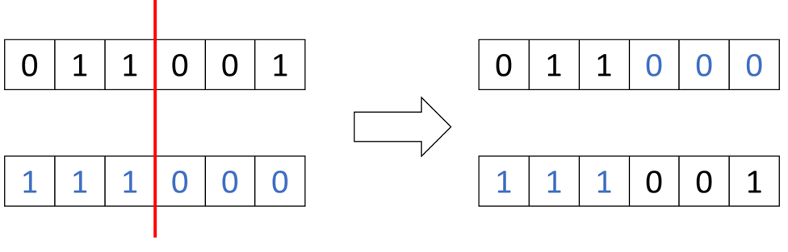

- Uniform Crossover

Every gene is exchanged between the a pair of randomly selected chromosomes with a certain probability, called as the swapping probability. Usually, the swapping probability value is taken to be 0.5.

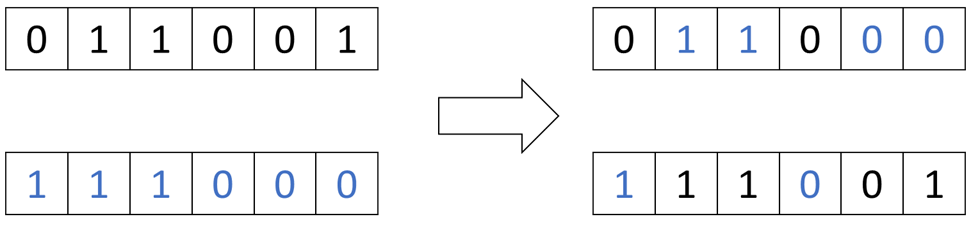

#### 3.4.1.2 Real-Valued

- Whole Arithmetic Crossover

Takes weighted sum of the two parental genes for each position. The weight is applied for all position. Let x = the value of the first parent and y = the value of the second parent for position/gene 1:

If the weight = 0.5 two offspring are identical

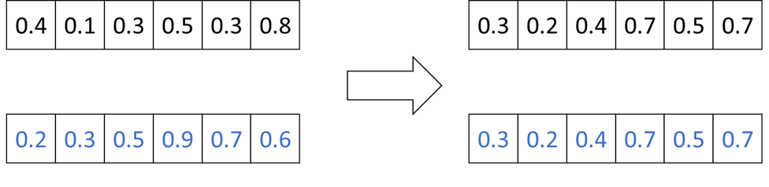

- Local Arithmetic Crossover

The local crossover is similar to the whole artihmetic crossover, but uses a random alpha for each position.

#### 3.4.1.3 Permutation

- One-point crossover

One-point crossover use only one random point as the marker where crossover should happen.

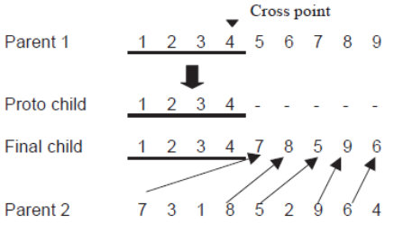

Nearchou, 2014

- Position-Based crossover

A number of positions from the first parent is randomly selected and fill the remaining position from the second parent.

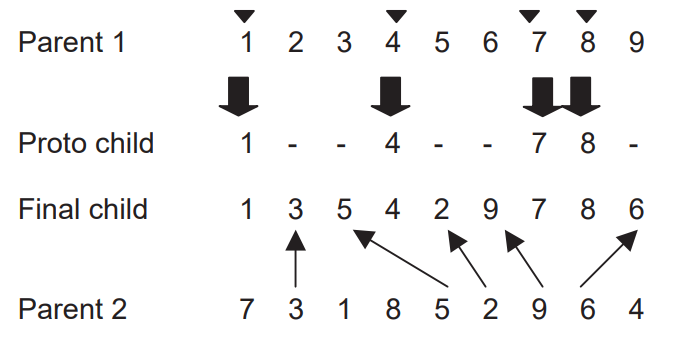

Nearchou, 2014

### 3.4.2 Mutation

A mutation means change in one or several genes inside the chromosome. Just like in the natural world, mutation rarely occur, thus they have a little probability to happen, usually set at 0.01. There are some example of mutations:

#### 3.4.2.1 Binary

- Random Mutation

Genes are randomly flipped from 1 to 0 or vice versa with uniform probability for each gene, meaning that each gene has the same chance to mutate with mutation rate or mutation probability set by the user.

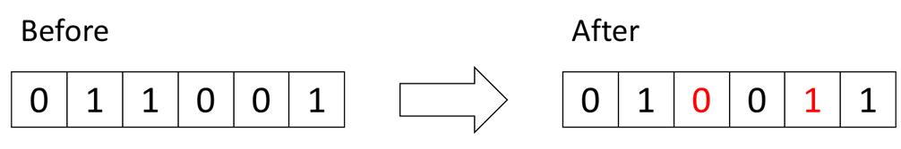

#### 3.4.2.2 Real Valued

- Uniform Random Mutation

Randomly mutate gene in a position with value from certain range with uniform distribution.

- Non Uniform Random Mutation

Select a random gene/position from a chromosome and assign a non-uniform random value to it.

#### 3.4.2.3 Permutation

- Adjacent Exchange Mutation

Two adjacent genes are swapped randomly.

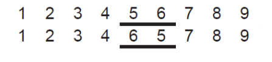

Nearchou, 2014

- Inverse Mutation

Inverse mutation is done by inversing the sequence between two random points.

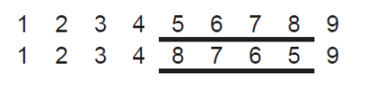

Nearchou, 2014

## 3.5 Application

Genetic Algorithm can be applied in various business problem. Since the algorithm is all about optimization, as long as there is an objective/fitness function to optimize, GA can be applied. Some example including production scheduling, knapsack problem (how many/how much we can load things in our bag or truck to maximize the space or the weight load), traveling salesman problem, etc. GA can also be applied in data science field, especially when we do hyper-parameter tuning to optimize the model performance. Certain problem may have it’s own unique parameter setting that can have better fitness value. For example, flowshop scheduling problem has been researched by Nearchou[^3]. Detailed overview and application of GA can be seen at Kramer’s work[^4]

## 3.6 Illustration

Let’s illustrate step-by-step how Genetic Algorithm works. Let’s say I have a set of item with respective point and weight (kg). I want to maximize the point, but the rules said that I can not bring items with total weight more than 15 kg. Whice items then should I choose in order to maximize my point?

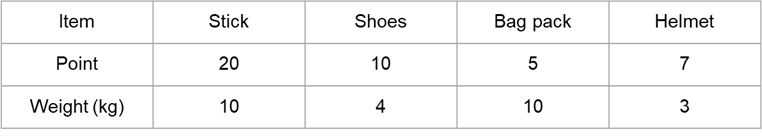

### 3.6.1 Define Encoding and Fitness Function

Since the problem is about whether bring certain item or not, then the solution should consists a logical value of each item. If the value is `1` or `TRUE`, then I should bring those item, and if value is `0` or `FALSE`, then I should not bring the item. By this logic, the encoding for our genetic algorithm should be binary encoding because it consists only 2 values (1 or 0).

The fitness function then, should be to maximize the total point.

$$Maximize \ Total\ Point = \Sigma_{i=1}^{k} \ P_k \ * \ chosen_k$$

- $Total\ Point$: The total point generated
- $k$: Number of item
- $P_k$: Point of item k
- $chosen_k$: logical value of each item (1 or 0)

Constrained to:

$$Total\ Weight <= 15$$

Since we have constraint, we need to incorporate the constraint into the fitness function. This is done to prevent an unfeasible solution (those that violate the constraint) to be chosen or selected as optimal value

$$Maximize\ Total\ Point = \Sigma_{i=1}^{k} \ P_k \ chosen_k - 2 \ (total\ weight - 15)^2$$

### 3.6.2 Initial Population

First, GA will randomly generate a population of solution. Here, we have a population of 4 solutions/indviduals. The binary value on each individuals are generated randomly.

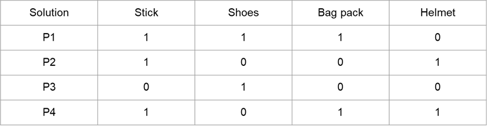

### 3.6.3 Fitness Assignment

Now we calculate the fitness value (total point) of each individuals based on the fitness function above. We can see that solution that violate the constraint (have total weight > 15) will have worse fitness function.

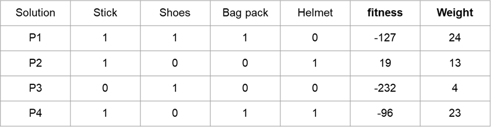

### 3.6.4 Selection

Now we will choose which individuals are gonna be crossed in order to get a new solution. We will use linear rank selection to select the `parent` solutions. We will choose 2 solutions since crossover require 2 `parent` solutions.

Linear ranking selection work as follows:

- Give rank to each individuals. Bigger rank is assigned for bigger fitness function. Individual 2 with fitness function of 19 is the highest, so it will be given rank 4.
- Calculate the probability of each individuals based on their rank. The sum of the rank is 10, so the probability of each solution is $Rank_i/10$.
- Chose solution randomly based on the probability. Solution with higher fitness function will naturally has higher chance to be chosen.

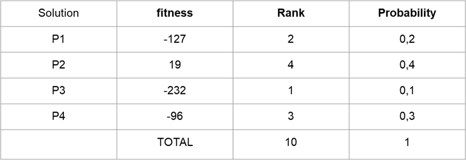

Let’s say for example, the first and second solution are chosen as the `parent`

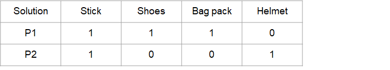

### 3.6.5 Crossover

Crossover means exchanging genes between two `parents` two create new solution called `child` solution. We will use the single-point crossover here. A single point is chosen randomly.

Let’s say the point is chosen to be between position 2 and 3. For the first child, it will have the first and second gene from the first parent, while the rest will be filled from the second parent. For the second child, it is the opposite, it will have the first and second gene from the second parent, while the rest will be filled from the first parent.

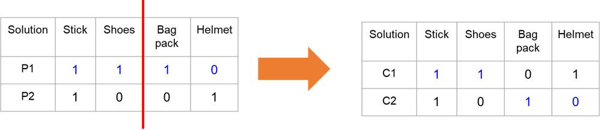

### 3.6.6 Mutation

Mutation is the change of value in the gene. Here we use random mutation. It will randomly swap the value of gene. If the gene in position 3 have value of 1, it would be switched into 0 and vice versa. Mutation is rarely occur, its probability can be set manually, but generally people use mutation probability of 0.1.

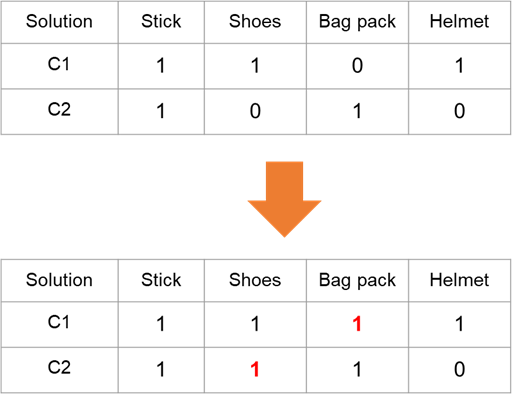

The selection, crossover, and mutation process will be repeated by choosing different parent until the number of children are the same with the population size of the parent. If the parent have population size of 4, then we would have a children population of 4.

### 3.6.7 Check Stopping Criteria

After mutation is done, we would check if it is time to stop the algorithm. Have we reached iteration 100? Do in the last 10 iterations the optimal fitness value didn’t change? If not, then the iteration would continue. After crossover and mutation, now we have parent population of 4 and children population of 4, so in total we now have 8 solutions. For the next iteration, we will only choose 4 individuals (in accordance with the initial population size) from the parent and the children. Generally, the individual with high fitness value will be chosen, so the next population will be better than the last one.

# 4 Genetic Algorithm with R

Here we will illustrate how GA can work using the `GA` package[^5][^6] both on business problem and on machine learning hyper-parameter tuning.

## 4.1 Business Application

### 4.1.1 Knapsack Problem

Suppose we have several items to deliver into the distribution center. However, our truck can only load up to total of 10 tons or 10000 kg, so we need to choose which items to deliver and maximize the weight loaded. You can directly solve this problem using the **Knapsack Method**, but you can also use Genetic Algorithm. Here we will see how GA deal with a constrained problem (weight should not exceed 10 tons or 10000 kg).

```r
df_item <- data.frame(item = c("Tires", "Bumper", "Engine", "Chasis", "Seat"),
                      freq = c(80,50,70,50,70),
                      weight = c(7, 17, 158, 100, 30))

df_item
```

| item | freq | weight |
| --- | --- | --- |
| Tires | 80 | 7 |
| Bumper | 50 | 17 |
| Engine | 70 | 158 |
| Chasis | 50 | 100 |
| Seat | 70 | 30 |

Each items have quantities and their respective weight.

Let’s create a new dataset with one observation correspond to only 1 item.

```r
df_item_long <- df_item[rep(rownames(df_item), df_item$freq), c("item","weight")]

head(df_item_long)
```

|  | item | weight |
| --- | --- | --- |
| 1 | Tires | 7 |
| 1.1 | Tires | 7 |
| 1.2 | Tires | 7 |
| 1.3 | Tires | 7 |
| 1.4 | Tires | 7 |
| 1.5 | Tires | 7 |

Let’s set the objective function.

$$Total\ Weight = \Sigma_{i=1}^{k} \ W_k \ * \ n_k$$

- $Total\ Weight$: The total weight (kg)
- $k$: Number of unique item
- $W_k$: Weight of item k
- $n_k$: Number of item k that is chosen

Constrained to:

$$Total\ Weight <= 10000$$

We will translate the objective function into `R function`.

```r
weightlimit <- 10000

evalFunc <- function(x) {
  # Subset only selected item based on the solution
  df <- df_item_long[x == 1, ]

  # calculate the total weight
  total_weight <- sum(df$weight)

  # Penalty if the total weight surpass the limit
  total_weight <- if_else(total_weight > weightlimit, 0, total_weight)

  return(total_weight)
}
```

Let’s run the algorithm. We will use binary encoding since the decision variables are logical (TRUE or FALSE), with each bit represent a single logical value whether the item is selected.

The parameter of the algorithm:

- `type`: Type of the gene encoding, here we use “binary”
- `fitness`: The fitness function that will be optimized
- `nBits`: Number of bits generated for the decision variables
- `pmutation`: probability of mutation, default 0.1
- `pcrossover`: probability of crossover, default 0.8
- `seed`: The value of random seed to get reproducible result
- `elitism`: Number of best solution that will survive in each iteration, default is the top 5% of the population.
- `maxiter`: Number of max iterations for the algorithm to run
- `popSize`: Number of solutions in a population
- `run`: Number of iteration before the algorithm stop if there is no improvement on the optimal fitness value
- `parallel`: Will we use parallel computing? Can be logical value or the number of core used
- `lower`: The lowest value of the permutation encoding
- `upper`: The highest value of the permutation encoding
- `keepBest`: A logical whether we save best solution in each generation in a separate slot

There are several options that can be chosen for each of the GA process. For example, the default parent selection of GA for binary is linear rank selection. The detailed default methods used on each encoding can be found at here[^7].

The `tic()` and `toc()` function is used to measure the computation time.

Here we will run a genetic algorithm with binary encoding, the fitness function would be the `evalFunc()` we created earlier. The population size (`popSize`) is 100 with maximum iteration (`maxiter`) is also 100. The maximum run (`run`) with no improvement is 20, after that the algorithm would be stopped. The `seed` for reproducibility is set at 123. Since we use binary encoding, the parameter `nBits` control the number of bits generated. Since each bit would represent a decision for each item, the number of bits is equal to the number of row from the `df_item_long`.

```r
tic()
library(GA)
ga_knapsack <- ga(type = "binary", fitness = evalFunc, popSize = 100,
                  maxiter = 100,
                  run = 20, nBits = nrow(df_item_long), seed = 123)
toc()
```

```
## 0.42 sec elapsed
```

The iteration stop at iterations 22 since after 20 iterations no improvement in the `total weight`. The optimal solution can be seen at `Fitness function value` which is 10000 (10,000 kg).

The `Solution` output is the solution that result in the optimal fitness value. We can choose one of them since they will result in the same fitness value. Let’s check one of them.

```r
summary(ga_knapsack)
```

[output not shown]

To check the summary, we use `summary()` function on GA object

```r
summary(ga_knapsack)
```

```
## -- Genetic Algorithm -------------------
##
## GA settings:
## Type                  =  binary
## Population size       =  100
## Number of generations =  100
## Elitism               =  5
## Crossover probability =  0.8
## Mutation probability  =  0.1
##
## GA results:
## Iterations             = 22
## Fitness function value = 10000
## Solutions =
##      x1 x2 x3 x4 x5 x6 x7 x8 x9 x10  ...  x319 x320
## [1,]  1  1  0  1  1  1  1  0  1   1          0    1
## [2,]  1  1  0  1  1  1  1  0  1   1          1    1
## [3,]  0  1  1  1  1  0  0  1  1   0          0    0
## [4,]  1  1  0  1  1  1  1  0  1   1          1    1
## [5,]  1  1  0  1  1  1  1  0  1   1          1    0
```

As we can see, there are several solutions for the problem, all of them have the same fitness value: 10000. Therefore, we have the flexibility to choose which solution we will pick. All optimal solution has no value greater than its constraint, which is also 10000.

Let’s check the plot of fitness value progression using `plot()`.

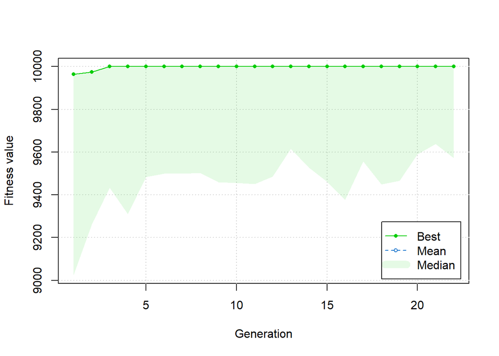

```r
plot(ga_knapsack)
```

We can see that the optimal solution (Best) is already achieved at iteration 3.

Let’s choose one of the solution as our decision.

```r
df_sol <- df_item_long[ga_knapsack@solution[1, ] == 1, ]

df_sol <- df_sol %>%
  group_by(item, weight) %>%
  summarise(freq = n()) %>%
  mutate(total_weigth = freq * weight)

df_sol
```

| item | weight | freq | total_weigth |
| --- | --- | --- | --- |
| Bumper | 17 | 21 | 357 |
| Chasis | 100 | 32 | 3200 |
| Engine | 158 | 33 | 5214 |
| Seat | 30 | 30 | 900 |
| Tires | 7 | 47 | 329 |

Let’s check the total weight

```r
sum(df_sol$total_weigth)
```

```
## [1] 10000
```

```r
ga_knapsack@solution
```

```
##      x1 x2 x3 x4 x5 x6 x7 x8 x9 x10 x11 x12 x13 x14 x15 x16 x17 x18 x19 x20 x21
## [1,]  1  1  0  1  1  1  1  0  1   1   1   0   1   0   1   1   1   1   1   0   1
## [2,]  1  1  0  1  1  1  1  0  1   1   1   0   1   0   1   1   1   1   1   0   1
## [3,]  0  1  1  1  1  0  0  1  1   0   1   1   1   0   1   1   0   1   1   0   1
## [4,]  1  1  0  1  1  1  1  0  1   1   1   0   1   1   1   0   1   1   1   0   1
## [5,]  1  1  0  1  1  1  1  0  1   1   1   0   1   0   1   1   1   1   1   0   1
##      x22 x23 x24 x25 x26 x27 x28 x29 x30 x31 x32 x33 x34 x35 x36 x37 x38 x39
## [1,]   0   1   1   1   0   0   1   1   0   0   0   1   0   0   0   1   0   0
## [2,]   0   1   1   1   0   0   1   1   0   0   0   1   0   0   0   1   0   0
## [3,]   0   1   1   1   1   1   1   1   0   1   1   1   1   0   0   1   0   1
## [4,]   0   1   1   1   0   0   1   1   0   0   0   1   0   0   0   1   0   0
## [5,]   0   1   1   1   0   0   1   1   0   0   0   1   0   0   0   1   0   0
##      x40 x41 x42 x43 x44 x45 x46 x47 x48 x49 x50 x51 x52 x53 x54 x55 x56 x57
## [1,]   0   1   1   1   0   0   1   1   0   0   0   1   0   1   0   1   0   0
## [2,]   0   1   1   1   0   0   1   1   0   0   0   1   0   1   0   1   0   0
```

[output cut: 111 more lines]

The optimal fitness value is same with the constraint, so we can fully load the vehicle based on it’s maximum capacity.

Let’s check the third solution

```r
df_sol <- df_item_long[ga_knapsack@solution[3, ] == 1, ]

df_sol <- df_sol %>%
  group_by(item, weight) %>%
  summarise(freq = n()) %>%
  mutate(total_weigth = freq * weight)

df_sol
```

| item | weight | freq | total_weigth |
| --- | --- | --- | --- |
| Bumper | 17 | 20 | 340 |
| Chasis | 100 | 27 | 2700 |
| Engine | 158 | 35 | 5530 |
| Seat | 30 | 36 | 1080 |
| Tires | 7 | 50 | 350 |

```r
sum(df_sol$total_weigth)
```

```
## [1] 10000
```

Even though the first solution and the second solution has different decisions, the fitness function or the total weights are the same, therefore both are optimal solutions and the decision to choose which one should be put into actual use is being handed to the decision maker.

### 4.1.2 Traveling Salesman Problem

The traveling salesperson problem (TSP) is one of the most widely discussed problems in combinatorial optimization. In its simplest form, consider a set of n cities with known symmetric intra-distances, the TSP involves finding an optimal route for visiting all the cities and return to the starting point such that the distance traveled is minimized. The set of feasible solutions is given by the total number of possible routes, which is equal to (n − 1)!/2.

Consider this `eurodist` dataset. It consists of 21 x 21 matrix of distance between cities. The total number of possible routes would be (21 - 1)!/2 = 1216451004088320000. Trying each one of them would take a great amount of time. Simple random search may fail to find the global optima.

```r
cities <- as.matrix(eurodist)

head(cities)
```

```
##           Athens Barcelona Brussels Calais Cherbourg Cologne Copenhagen Geneva
## Athens         0      3313     2963   3175      3339    2762       3276   2610
## Barcelona   3313         0     1318   1326      1294    1498       2218    803
## Brussels    2963      1318        0    204       583     206        966    677
## Calais      3175      1326      204      0       460     409       1136    747
## Cherbourg   3339      1294      583    460         0     785       1545    853
## Cologne     2762      1498      206    409       785       0        760   1662
##           Gibraltar Hamburg Hook of Holland Lisbon Lyons Madrid Marseilles
## Athens         4485    2977            3030   4532  2753   3949       2865
## Barcelona      1172    2018            1490   1305   645    636        521
## Brussels       2256     597             172   2084   690   1558       1011
## Calais         2224     714             330   2052   739   1550       1059
## Cherbourg      2047    1115             731   1827   789   1347       1101
## Cologne        2436     460             269   2290   714   1764       1035
##           Milan Munich Paris Rome Stockholm Vienna
## Athens     2282   2179  3000  817      3927   1991
## Barcelona  1014   1365  1033 1460      2868   1802
## Brussels    925    747   285 1511      1616   1175
## Calais     1077    977   280 1662      1786   1381
## Cherbourg  1209   1160   340 1794      2196   1588
## Cologne     911    583   465 1497      1403    937
```

Since the objective is to minimize the distance, the fitness value would be in negative.

```r
tsp_fitness <- function(x) {
  x <- c(x, x[1])

  # create from-to matrix
  route <- embed(x, 2)[, 2:1]

 # Calculate distance
 distance <- -sum(cities[route])
 return(distance)
 }
```

Let’s run the algorithm.

```r
tic()
ga_cities <- ga(type = "permutation", fitness = tsp_fitness, monitor = F,
         lower = 1, upper = nrow(cities), popSize = 100, maxiter = 5000,
         run = 500, seed = 123)
summary(ga_cities)
```

```
## -- Genetic Algorithm -------------------
##
## GA settings:
## Type                  =  permutation
## Population size       =  100
## Number of generations =  5000
## Elitism               =  5
## Crossover probability =  0.8
## Mutation probability  =  0.1
##
## GA results:
## Iterations             = 1739
## Fitness function value = -12919
## Solutions =
##      x1 x2 x3 x4 x5 x6 x7 x8 x9 x10  ...  x20 x21
## [1,] 15  2  9 12 14  5 18  4  3  11         8  13
## [2,]  5 18  4  3 11  7 20 10  6  17        12  14
## [3,]  1 21 17  6 10 20  7 11  3   4        16  19
## [4,]  6 10 20  7 11  3  4 18  5  14        21  17
## [5,]  1 19 16  8 13 15  2  9 12  14        17  21
```

```r
toc()
```

```
## 13.28 sec elapsed
```

We have 5 solutions/routes that has the minimal distance. Transform the information into readable route

```r
route_optimal <- ga_cities@solution

cities_name <- names(cities[1 , ])

cities_name <- apply(route_optimal, 1, function(x) {cities_name[x]})

apply(cities_name, 2, paste, collapse = " > ")
```

```
## [1] "Marseilles > Barcelona > Gibraltar > Lisbon > Madrid > Cherbourg > Paris > Calais > Brussels > Hook of Holland > Copenhagen > Stockholm > Hamburg > Cologne > Munich > Vienna > Athens > Rome > Milan > Geneva > Lyons"
## [2] "Cherbourg > Paris > Calais > Brussels > Hook of Holland > Copenhagen > Stockholm > Hamburg > Cologne > Munich > Vienna > Athens > Rome > Milan > Geneva > Lyons > Marseilles > Barcelona > Gibraltar > Lisbon > Madrid"
## [3] "Athens > Vienna > Munich > Cologne > Hamburg > Stockholm > Copenhagen > Hook of Holland > Brussels > Calais > Paris > Cherbourg > Madrid > Lisbon > Gibraltar > Barcelona > Marseilles > Lyons > Geneva > Milan > Rome"
## [4] "Cologne > Hamburg > Stockholm > Copenhagen > Hook of Holland > Brussels > Calais > Paris > Cherbourg > Madrid > Lisbon > Gibraltar > Barcelona > Marseilles > Lyons > Geneva > Milan > Rome > Athens > Vienna > Munich"
## [5] "Athens > Rome > Milan > Geneva > Lyons > Marseilles > Barcelona > Gibraltar > Lisbon > Madrid > Cherbourg > Paris > Calais > Brussels > Hook of Holland > Copenhagen > Stockholm > Hamburg > Cologne > Munich > Vienna"
```

Better representation for the route can be visualized through network or graph.

### 4.1.3 Production Scheduling

Supposed that we have various units of car to be produced at our manufacturing plant. There are 7 different types of product colors. If the following unit has different color than the previous car, there will changeover cost (cost incurred due to change in product types), such as the cost of material required to clean the equipment from the previous paint color. There are many way to optimize the color sequence, but we will use the simplest one in here for illustration. We want to minimize the number of setup, making the number of color switch or changover occur less, therefore the changeover cost can also be minimized.

First we import the data.

```r
df_car <- read.csv("data_input/car_data.csv")

df_car
```

| X | color |
| --- | --- |
| 1 | White |
| 2 | White |
| 3 | White |
| 4 | Gray |
| 5 | Silver |
| 6 | Black |
| 7 | Silver |
| 8 | White |
| 9 | Orange |
| 10 | Silver |

[output cut: 18 more lines]

The objective function will be:
$$S = 1 + \Sigma_{k=2}^{DT} \ S_k$$

- $S$ = number of setup
- $D_T$ = Number of car/unit to be produced
- $k$ = The position of car in the sequence
- $S_k$ = Is setup required? 1 if the next car ($K+1$) doesn’t have the same color with the current $k^{th}$ car, 0 if the next car does

We will translate the objective function into an R function of `min_setup`. The algorithm in `GA` package run in context of maximization, so in order to do a minimization problem, we will make our fitness value negative.

```r
min_setup <- function(x){
  df <- df_car[x, ]
  print(df)
  S <- df %>%
  mutate(color_next = lead(color),
         setup = if_else(color == color_next, 0, 1)) %>%
  head(nrow(df)-1) %>%
  pull("setup") %>%
  sum() + 1
  S <- -S
  return(S)
}
```

Now we run the algorithm. Since the problem is a scheduling problem, we will encode our solutions with permutation encoding. We will stop the algorithm if the number of iteration has reached 1000 iterations or if in 100 iterations there is no improvement in the optimal fitness value.

**IMPORTANT** The choice of population size and the number of iteration will greatly affect the performance of GA. If the population size is too little, there will be limited *gene pool* in our population so the the new solutions will not differ too much from the previous generations. If the number of iterations is too little, there will not be enough time for the algorithm to find new optimal solutions. `GA` package can be run with parallel computing.

```r
tic()
ga_schedule <- ga(type = "permutation", fitness = min_setup, lower = 1, upper = nrow(df_car),
                  seed = 123, maxiter = 1000, popSize = 100, elitism = 50, monitor = F,
                  run = 100, parallel = T)

summary(ga_schedule)
```

```
## -- Genetic Algorithm -------------------
##
## GA settings:
## Type                  =  permutation
## Population size       =  100
## Number of generations =  1000
## Elitism               =  50
## Crossover probability =  0.8
## Mutation probability  =  0.1
##
## GA results:
## Iterations             = 223
## Fitness function value = -6
## Solutions =
##       x1 x2 x3 x4 x5 x6 x7 x8 x9 x10  ...  x27 x28
## [1,]   1 27  8  2 23  3 16 20 12  15        14  22
## [2,]  14 22 21  6 12 15 16 27  8   2        19   9
## [3,]  14 22 21  6 12 15 16  1 27   3        18  11
## [4,]  21  6 12 15 27  2 16  8 23   1        14  22
## [5,]  21  6 12 15  1  3 23  8 27  16        18  11
## [6,]  14 22 21 12  6 15 27  2 20   1        19   9
## [7,]   9 19 14 22 21  6 12 15  7  28        11  18
## [8,]  21  6 12 15  1 27  2 23  3  20        14  22
## [9,]  21  6 12 15 16  1 27  3 20   8        14  22
## [10,] 21  6 12 15  2 23 16 20 27   1        14  22
##  ...
## [55,] 21 12  6 15  1  3 27 16 20   8        14  22
## [56,] 16  2 27 23  8  1  3 20 21   6        14  22
```

```r
toc()
```

```
## 75.36 sec elapsed
```

We can plot the progression of the algorithm by using `plot()` function on the GA object.

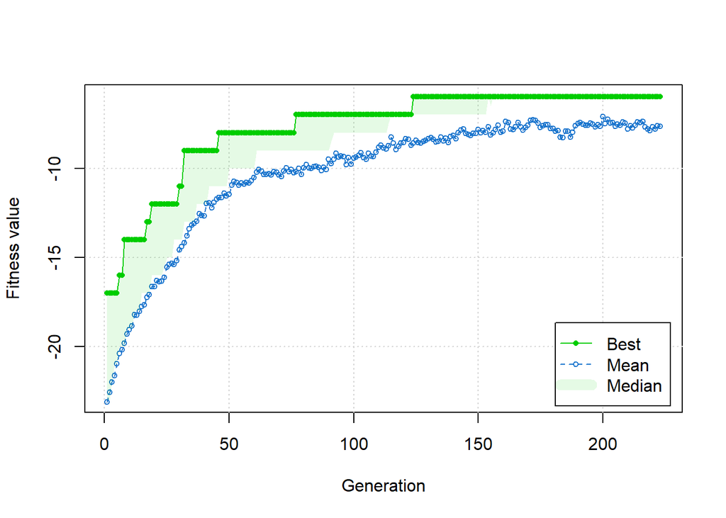

```r
plot(ga_schedule)
```

Let’s put the optimal sequence to our data. The resulting data frame will be our production schedule. Since there are multiple solutions, let’s just look at the first two optimal solutions.

The first solution:

```r
df_car[ga_schedule@solution[1, ], ]
```

|  | X | color |
| --- | --- | --- |
| 1 | 1 | White |
| 27 | 27 | White |
| 8 | 8 | White |
| 2 | 2 | White |
| 23 | 23 | White |
| 3 | 3 | White |
| 16 | 16 | White |
| 20 | 20 | White |
| 12 | 12 | Black |
| 15 | 15 | Black |

[output cut: 18 more lines]

The second solution:

```r
df_car[ga_schedule@solution[2, ], ]
```

|  | X | color |
| --- | --- | --- |
| 14 | 14 | Solid White |
| 22 | 22 | Solid White |
| 21 | 21 | Black |
| 6 | 6 | Black |
| 12 | 12 | Black |
| 15 | 15 | Black |
| 16 | 16 | White |
| 27 | 27 | White |
| 8 | 8 | White |
| 2 | 2 | White |

[output cut: 18 more lines]

Even though the first solution and the second solution has different sequence, the fitness function or the number of setup are the same, therefore both are optimal solutions and the decision to choose which one should be put into actual use is being handed to the decision maker, in these case, the production control staff.

There are still many application of GA in various field, especially in manufacturing and engineering process. As long as there is a fitness function and decision variables, GA can be appllied toward the problem.

## 4.2 Hyper-Parameter Tuning on Machine Learning Model

Now we will try to apply the genetic algorithm to tune and optimize our machine learning model. We will use the `attrition` dataset.

### 4.2.1 Import Data

```r
attrition <- read.csv("data_input/attrition.csv")

attrition <- attrition %>%
  mutate(job_involvement = as.factor(job_involvement),
         education = as.factor(education),
         environment_satisfaction = as.factor(environment_satisfaction),
         performance_rating = as.factor(performance_rating),
         relationship_satisfaction = as.factor(relationship_satisfaction),
         work_life_balance = as.factor(work_life_balance),
         attrition = factor(attrition, levels = c("yes", "no")))

attrition
```

| attrition | age | business_travel | daily_rate | department | distance_from_home | education | education_field | employee_count | employee_number | environment_satisfaction | gender | hourly_rate | job_involvement | job_level | job_role | job_satisfaction | marital_status | monthly_income | monthly_rate | num_companies_worked | over_18 | over_time | percent_salary_hike | performance_rating | relationship_satisfaction | standard_hours | stock_option_level | total_working_years | training_times_last_year | … |
| --- | --- | --- | --- | --- | --- | --- | --- | --- | --- | --- | --- | --- | --- | --- | --- | --- | --- | --- | --- | --- | --- | --- | --- | --- | --- | --- | --- | --- | --- | --- |
| yes | 41 | travel_rarely | 1102 | sales | 1 | 2 | life_sciences | 1 | 1 | 2 | female | 94 | 3 | 2 | sales_executive | 4 | single | 5993 | 19479 | 8 | y | yes | 11 | 3 | 1 | 80 | 0 | 8 | 0 | … |
| no | 49 | travel_frequently | 279 | research_development | 8 | 1 | life_sciences | 1 | 2 | 3 | male | 61 | 2 | 2 | research_scientist | 2 | married | 5130 | 24907 | 1 | y | no | 23 | 4 | 4 | 80 | 1 | 10 | 3 | … |
| yes | 37 | travel_rarely | 1373 | research_development | 2 | 2 | other | 1 | 4 | 4 | male | 92 | 2 | 1 | laboratory_technician | 3 | single | 2090 | 2396 | 6 | y | yes | 15 | 3 | 2 | 80 | 0 | 7 | 3 | … |
| no | 33 | travel_frequently | 1392 | research_development | 3 | 4 | life_sciences | 1 | 5 | 4 | female | 56 | 3 | 1 | research_scientist | 3 | married | 2909 | 23159 | 1 | y | yes | 11 | 3 | 3 | 80 | 0 | 8 | 3 | … |
| no | 27 | travel_rarely | 591 | research_development | 2 | 1 | medical | 1 | 7 | 1 | male | 40 | 3 | 1 | laboratory_technician | 2 | married | 3468 | 16632 | 9 | y | no | 12 | 3 | 4 | 80 | 1 | 6 | 3 | … |
| no | 32 | travel_frequently | 1005 | research_development | 2 | 2 | life_sciences | 1 | 8 | 4 | male | 79 | 3 | 1 | laboratory_technician | 4 | single | 3068 | 11864 | 0 | y | no | 13 | 3 | 3 | 80 | 0 | 8 | 2 | … |
| no | 59 | travel_rarely | 1324 | research_development | 3 | 3 | medical | 1 | 10 | 3 | female | 81 | 4 | 1 | laboratory_technician | 1 | married | 2670 | 9964 | 4 | y | yes | 20 | 4 | 1 | 80 | 3 | 12 | 3 | … |
| no | 30 | travel_rarely | 1358 | research_development | 24 | 1 | life_sciences | 1 | 11 | 4 | male | 67 | 3 | 1 | laboratory_technician | 3 | divorced | 2693 | 13335 | 1 | y | no | 22 | 4 | 2 | 80 | 1 | 1 | 2 | … |
| no | 38 | travel_frequently | 216 | research_development | 23 | 3 | life_sciences | 1 | 12 | 4 | male | 44 | 2 | 3 | manufacturing_director | 3 | single | 9526 | 8787 | 0 | y | no | 21 | 4 | 2 | 80 | 0 | 10 | 2 | … |
| no | 36 | travel_rarely | 1299 | research_development | 27 | 3 | medical | 1 | 13 | 3 | male | 94 | 3 | 2 | healthcare_representative | 3 | married | 5237 | 16577 | 6 | y | no | 13 | 3 | 2 | 80 | 2 | 17 | 3 | … |

[output cut: 1460 more lines]

### 4.2.2 Cross-Validation

We split the data into training set and testing dataset, with 80% of the data will be used as the training set.

```r
set.seed(123)
intrain <- initial_split(attrition, prop = 0.8, strata = "attrition")

intrain
```

```
## <1177/293/1470>
```

### 4.2.3 Data Preprocessing

We will preprocess the data with the following step:

- Upsample to increase the number of the minority class and prevent class imbalance
- Scaling all of the numeric variables
- Remove numeric variable with near zero variance
- Use PCA to reduce dimensions with threshold of 90% information kept
- Remove `over_18` variable since it only has 1 levels of factor

```r
rec <- recipe(attrition ~ ., data = training(intrain)) %>%
  step_upsample(attrition) %>%
  step_scale(all_numeric()) %>%
  step_nzv(all_numeric()) %>%
  step_pca(all_numeric(), threshold = 0.9) %>%
  step_rm(over_18) %>%
  prep()

data_train <- juice(rec)
data_test <- bake(rec, testing(intrain))

data_train
```

| business_travel | department | education | education_field | environment_satisfaction | gender | job_involvement | job_role | marital_status | over_time | performance_rating | relationship_satisfaction | work_life_balance | attrition | PC1 | PC2 | PC3 | PC4 |
| --- | --- | --- | --- | --- | --- | --- | --- | --- | --- | --- | --- | --- | --- | --- | --- | --- | --- |
| travel_frequently | sales | 1 | life_sciences | 3 | male | 1 | sales_representative | single | yes | 3 | 4 | 3 | yes | -7.642926 | -2.705202528 | 1.2796635379 | 1.589558e-01 |
| travel_frequently | human_resources | 3 | human_resources | 3 | female | 2 | human_resources | divorced | no | 3 | 3 | 2 | yes | -7.282435 | -1.021044341 | -1.1119174903 | 6.797211e-01 |
| travel_rarely | research_development | 1 | medical | 2 | male | 3 | manager | married | yes | 3 | 4 | 4 | yes | -9.580775 | 2.069242683 | -1.1362920145 | -2.684873e-01 |
| travel_rarely | research_development | 3 | technical_degree | 3 | male | 2 | laboratory_technician | divorced | no | 3 | 1 | 2 | yes | -7.927918 | -1.636391585 | -0.6725747947 | 1.229776e-01 |
| travel_frequently | sales | 3 | life_sciences | 3 | male | 3 | sales_executive | single | yes | 3 | 2 | 2 | yes | -9.157903 | 6.287122598 | 1.7134183891 | 6.571328e-01 |
| travel_frequently | human_resources | 3 | human_resources | 1 | female | 2 | human_resources | married | no | 3 | 1 | 3 | yes | -7.340024 | -2.377575278 | 0.3173385606 | 9.399083e-01 |
| travel_rarely | sales | 3 | life_sciences | 2 | male | 2 | sales_executive | married | no | 3 | 4 | 3 | yes | -8.037962 | 2.094017100 | 1.0597070457 | -5.976440e-01 |
| travel_rarely | sales | 3 | life_sciences | 3 | female | 3 | sales_executive | married | no | 4 | 3 | 3 | yes | -11.000355 | 0.542000160 | -0.8184683954 | 7.324971e-01 |
| travel_rarely | research_development | 4 | life_sciences | 1 | male | 3 | research_scientist | married | yes | 3 | 3 | 4 | yes | -8.925547 | 0.459817066 | -2.5938991697 | -8.709578e-01 |
| travel_rarely | research_development | 5 | technical_degree | 3 | female | 2 | research_scientist | married | no | 3 | 2 | 4 | yes | -7.648735 | -1.672713519 | 0.1705978079 | 1.455439e+00 |

[output cut: 1964 more lines]

### 4.2.4 Create Fitness Function

We will train the model using `random forest`. We will optimize the `mtry` (number of nodes in each tree) and the `min_n` (minimum number of member on each tree in order to be splitted) value by maximizing the model accuracy on the testing dataset. Since the number of `mtry` and `min_n` is integer, we better use binary encoding instead of real-valued encoding.

We will set the range of `mtry` from 1 to 32. We will limit the range of `min_n` from 1 to 128. Let’s check how many bits we need to cover those numbers.

```r
# max value of mtry = 32
2^5
```

```
## [1] 32
```

```r
# max value of min_n = 128
2^7
```

```
## [1] 128
```

So, we will need at least 12 bits of binary. If the converted value of bits for `mtry` or `min_n` is 0, we change it to 1.

We will write the model as fitness function. We will maximize the accuracy of our model on the testing dataset.

```r
fit_function <- function(x){
  a <- binary2decimal(x[1:5])
  b <- binary2decimal(x[6:12])

  if (a == 0) {
    a <- 1
  }
  if (b == 0) {
    b <- 1
  }
  if (a > 17) {
    a <- 17
  }

#define model spec
model_spec <- rand_forest(
  mode = "classification",
  mtry = a,
  min_n = b,
  trees = 500)

#define model engine
model_spec <- set_engine(model_spec,
                         engine = "ranger",
                         seed = 123,
                         num.threads = parallel::detectCores(),
                         importance = "impurity")

#model fitting
set.seed(123)
model <- fit_xy(
  object = model_spec,
  x = select(data_train, -attrition),
  y = select(data_train, attrition)
)

pred_test <- predict(model, new_data = data_test %>% select(-attrition))
acc <- accuracy_vec(truth = data_test$attrition, estimate = pred_test$.pred_class)
return(acc)
}
```

### 4.2.5 Run the Algorithm

**IMPORTANT** Since some model require a lot of time to train, you may need to be extra careful on choosing the population size and the number of iteration. If you don’t have a problem to run the GA on a long period of time, than you may choose bigger population size and number of iterations. Here I will set the population size to be only 100 and the maximum number of iteration is 100. You can use `parallel = TRUE` if you want faster computation with parallel computing.

We will try to use tournament selection instead of the default linear rank selection.

```r
tic()
ga_rf <- ga(type = "binary", fitness = fit_function, nBits = 12, seed = 123,
            popSize = 100, maxiter = 100, run = 10, parallel = T,
            selection = gabin_tourSelection)
summary(ga_rf)
```

```
## -- Genetic Algorithm -------------------
##
## GA settings:
## Type                  =  binary
## Population size       =  100
## Number of generations =  100
## Elitism               =  5
## Crossover probability =  0.8
## Mutation probability  =  0.1
##
## GA results:
## Iterations             = 18
## Fitness function value = 0.8805461
## Solutions =
##      x1 x2 x3 x4 x5 x6 x7 x8 x9 x10 x11 x12
## [1,]  0  0  0  0  1  0  0  1  0   0   1   0
## [2,]  0  0  0  0  0  0  0  1  0   0   1   0
```

```r
toc()
```

```
## 697.92 sec elapsed
```

Let’s plot the progression of GA

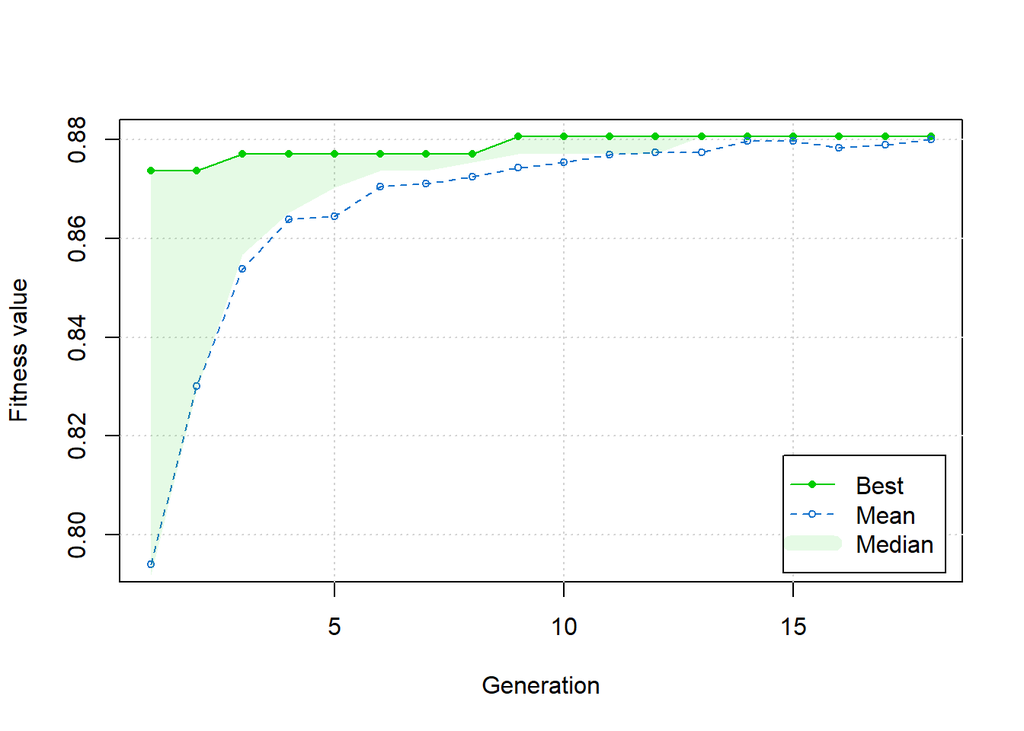

```r
plot(ga_rf)
```

Let’s check each decision variables and the accuracy that is used as the fitness value.

```r
# Transform decision variables into data frame
ga_rf_pop <- as.data.frame(ga_rf@population)

# Convert decision variables into mtry and min_n
ga_mtry <- apply(ga_rf_pop[ , 1:5], 1, binary2decimal)
ga_min_n <- apply(ga_rf_pop[ , 6:12], 1, binary2decimal)

# Show the list of solutions in the final population
data.frame(mtry = ga_mtry,
           min_n = ga_min_n,
           accuracy = ga_rf@fitness) %>%
  mutate(mtry = ifelse(mtry == 0, 1, mtry),
         min_n = ifelse(min_n == 0, 1, min_n),
         mtry = ifelse(mtry > 17, 17, mtry)) %>%
  distinct() %>%
  arrange(desc(accuracy))
```

| mtry | min_n | accuracy |
| --- | --- | --- |
| 1 | 18 | 0.8805461 |
| 1 | 26 | 0.8771331 |
| 1 | 27 | 0.8737201 |
| 1 | 82 | 0.8668942 |
| 4 | 18 | 0.8600683 |

### 4.2.6 Compare with K-fold Cross Validation

You may want to compare the computation time of GA with the required time for repeated K-fold cross-validation using the conventional `caret` package. We will use k = 5 and 10 repeats.

```r
tic()
set.seed(123)
ctrl <- trainControl(method="repeatedcv", number=5, repeats=10)
attrition_forest <- train(attrition ~ ., data=data_train, method="rf", trControl = ctrl)
toc()
```

```
## 544.64 sec elapsed
```

```r
attrition_forest
```

```
## Random Forest
##
## 1974 samples
##   17 predictor
##    2 classes: 'yes', 'no'
##
## No pre-processing
## Resampling: Cross-Validated (5 fold, repeated 10 times)
## Summary of sample sizes: 1580, 1579, 1578, 1580, 1579, 1578, ...
## Resampling results across tuning parameters:
##
##   mtry  Accuracy   Kappa
##    2    0.9462064  0.8924131
##   22    0.9587116  0.9174242
##   42    0.9475654  0.8951309
##
## Accuracy was used to select the optimal model using the largest value.
## The final value used for the model was mtry = 22.
```

Let’s check the accuracy of the random forest model with `caret`

```r
pred_rf <- predict(attrition_forest, newdata = data_test)
accuracy_vec(truth = data_test$attrition, estimate = pred_rf)
```

```
## [1] 0.8634812
```

The model performance by GA is better than those optimized with simple K-fold cross validation, even though GA require more time to compute. This trade-off of computation time vs performance should be considered.

# 5 Conclusion

Optimization problem is one of many concern in business, which may seek to maximize profit and minimize loss. Machine learning apply optimization on their method of training model to get the best possible result. GA is an optimization algorithm that can be applied in various fields, including data science. If a data scientist can harness the benefit of GA, he can get more optimal model with better performance. The downside of GA is that it require time to compute since it belong to the group of search algorithm, where it explore possible solution efficiently compared to random search.

# 6 What’s Next

Research in evolutionary algorithm is still growing in recent years, some discussed the best crossover and mutation scheme, while the others improve the method. GA can also be applied for multi-objective optimization, where two or more conflicting objectives need to be optimized. Several method such as NSGA-II or SPEA2 is a popular GA method that can be used to do a multi-objective optimization. Many of new multi-objective or even many-objective (those with more than 3 objectives) evolutionary algorithms are derived from this two methods[^8]. One of the most interesting application of this is in manufacturing sector, especially for scheduling problem, where complex combinatorial optimization problem need to be solved since they have great impact toward productivity and cost[^9].

# 7 Reference

[^1]: [Treiber, N. A., and O. Kramer. 2015. Evolutionary feature weighting for wind power prediction with nearest neighbor regression. *IEEE Congress on Evolutionary Computation (CEC)*, 332-337.](https://ieeexplore.ieee.org/abstract/document/7256910)
[^2]: Oehmcke, S., Heinermann, J., and Kramer, O. 2015. Analysis of diversity methods for evolutionary multi-objective ensemble classifiers. *Applications of Evolutionary Computation (EvoStar)*, 567–578.
[^3]: [Nearchou, A. C. 2004. The Effect of Various Operators on The Genetic Search for Large Scheduling Problems. *International Journal of productions Economics*, 88, 191-203.](https://www.sciencedirect.com/science/article/abs/pii/S0925527303001841)
[^4]: [Kramer, Oliver. 2017. *Genetic Algorithm Essentials*. Gewerbestrasse: Springer.](https://www.springer.com/gp/book/9783319521558)
[^5]: [Scrucca, Luca. A quick tour of GA](http://luca-scr.github.io/GA/articles/GA.html)
[^6]: [Scrucca, Luca. 2013. GA: A Package for Genetic Algorithms in R. *Journal of Statistical Software*, 3(4).](https://www.jstatsoft.org/article/view/v053i04/v53i04.pdf)
[^7]: [GA Package: A Function For Setting Or Retrieving Defaults Genetic Operators](https://www.rdocumentation.org/packages/GA/versions/3.2/topics/gaControl)
[^8]: [Chand, Shelvin and Markus Wagner. 2015. Evolutionary many-objective optimization: A quick-start guide. *Surveys in Operations Research and Management Science*, 20(2), 35-42.](https://www.sciencedirect.com/science/article/pii/S1876735415000148)
[^9]: [Gen, M., & Lin, L. 2013. Multiobjective evolutionary algorithm for manufacturing scheduling problems: state-of-the-art survey. *Journal of Intelligent Manufacturing*, 25(5), 849–866.](https://lvk.cs.msu.su/~vbabernov/2019-o/m1/2013_LIN_Multiobjective%20evolutionary%20algorithm%20for%20manufacturing.pdf)